# Distribuições de probabilidade complementares

Niege Felix & Samuel Lima

Vamos falar sobre Distribuição de probabilidades complementares. Podemos usar 03 tipos de distribuição:

1. Distribuição Beta
2. Distribuições para dados zero-inflacionados
3. Distribuições Tweedie

Vamos explorar o que elas representam e seus pressupostos:

# 1 Distribuição Beta

## 1.1 Descrição: A distribuição Beta é contínua e definida no intervalo (0,1).

É muito usada para modelar proporções, probabilidades e taxas, como:

- Cobertura vegetal (em %);
- Proporção de biomassa viva/morta;
- Fração de tempo gasto em determinada atividade;
- Probabilidade de ocorrência.

A distribuição **Beta** é definida para valores $y$ no intervalo $(0, 1)$.

A sua **função densidade de probabilidade** é dada por:

$$f(y; \alpha, \beta) = \frac{y^{\alpha - 1}(1 - y)^{\beta - 1}}{B(\alpha,
\beta)}, \quad 0 < y < 1$$

onde $\alpha > 0$ e $\beta > 0$ são parâmetros de forma e $B(\alpha, \beta)$ é a função Beta.

## 1.2 Exemplo em R

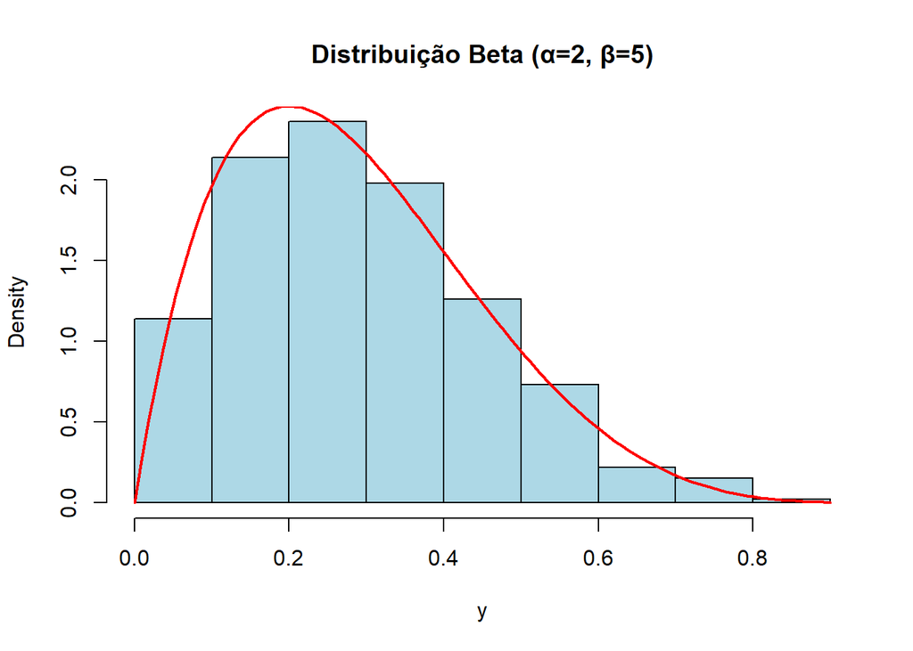

```r
# Simulando dados de uma distribuição Beta
set.seed(123)
y <- rbeta(1000, shape1 = 2, shape2 = 5)

# Visualizando a densidade
hist(y, probability = TRUE, col = "lightblue", main = "Distribuição Beta (α=2, β=5)")
curve(dbeta(x, 2, 5), add = TRUE, col = "red", lwd = 2)
```

```r
# Exemplo de cálculo da densidade para um valor específico
dbeta(0.5, shape1 = 2, shape2 = 5)
```

```
## [1] 0.9375
```

## 1.3 Pressupostos da Distribuição Beta

A **distribuição Beta** é adequada para modelar **variáveis contínuas limitadas ao intervalo (0, 1)**, como proporções e probabilidades.  
Antes de utilizá-la, é importante verificar se os seguintes **pressupostos** são atendidos:

### 1.3.1 1. Intervalo dos dados

Os valores da variável resposta $y$ devem estar **entre 0 e 1**, isto é:

$$0 < y_i < 1$$

Se existirem valores iguais a 0 ou 1, eles devem ser ajustados (por exemplo, usando a transformação proposta por Smithson & Verkuilen, 2006):

$$y^* = \frac{y (n - 1) + 0.5}{n}$$

onde $n$ é o tamanho da amostra.

### 1.3.2 2. Natureza contínua dos dados

Os dados devem ser **contínuos**, e não discretos.  
A distribuição Beta **não é apropriada** para contagens ou dados binários.

### 1.3.3 3. Forma da distribuição

A forma da distribuição deve ser **assimétrica** ou **em forma de sino**, dentro do intervalo (0,1), podendo variar conforme os parâmetros $\alpha$ e $\beta$.  
É recomendável inspecionar graficamente os dados:

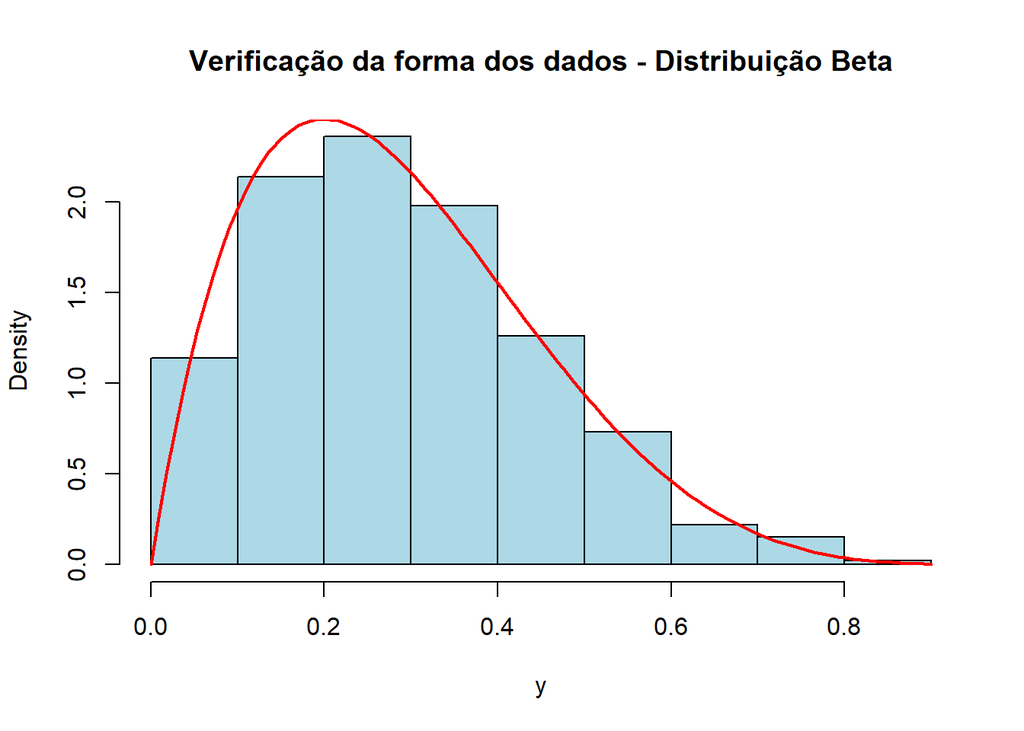

```r
# Exemplo de verificação visual
set.seed(123)
y <- rbeta(1000, shape1 = 2, shape2 = 5)

hist(y, probability = TRUE, col = "lightblue",
     main = "Verificação da forma dos dados - Distribuição Beta")
curve(dbeta(x, 2, 5), add = TRUE, col = "red", lwd = 2)
```

# 2 Distribuição para dados zero-inflacionados

Dados **zero-inflacionados** são aqueles em que ocorre um **número de zeros maior do que o esperado** sob uma distribuição estatística tradicional (como Poisson, Binomial ou Gama).

Esses zeros “extras” podem vir de duas fontes:

1. **Zeros estruturais**: representam impossibilidade real de ocorrência  
   (por exemplo, uma espécie que nunca ocorre em determinado habitat);
2. **Zeros amostrais**: representam a ausência ocasional de ocorrência  
   (a espécie *poderia* ocorrer, mas não foi observada).

### 2.0.1 Formulação geral

Um modelo zero-inflacionado combina duas partes:

1. Uma **distribuição discreta ou contínua** para os valores positivos (ex.: Poisson, Binomial Negativa ou Gama);
2. Uma **mistura com um ponto de probabilidade extra em zero**.

A probabilidade total é dada por:

$$P(Y = 0) = \pi + (1 - \pi) \cdot f(0; \theta)$$

$$P(Y = y) = (1 - \pi) \cdot f(y; \theta), \quad y > 0$$

onde:  
- $\pi$ é a probabilidade de um zero estrutural;  
- $f(y; \theta)$ é a função de probabilidade (ou densidade) da distribuição principal.

### 2.0.2 Tipos de distribuições zero-inflacionadas

| Distribuição | Tipo de dado | Base da mistura | Uso comum |
| --- | --- | --- | --- |
| **ZIP** (Zero-Inflated Poisson) | Contagens inteiras | Poisson | Abundância de indivíduos |
| **ZINB** (Zero-Inflated Negative Binomial) | Contagens com sobredispersão | Binomial Negativa | Dados ecológicos superdispersos |
| **ZIG** (Zero-Inflated Gamma) | Contínuos positivos com zeros | Gama | Biomassa, BPUE, tempo de decomposição |
| **ZIBeta** (Zero-Inflated Beta) | Proporções com zeros exatos | Beta | Cobertura vegetal, taxas, proporções |

Modelos em dois estágios (ZAP/ZANB) Também assume que os dados foram gerados em duas etapas: - Processo binário: decide se a espécie está presente ou ausente; logo, atua como barreira separando os zeros dos números positivos. Foco: presença da espécie.

- Processo Poisson/BN truncado: considera que as contagens surgiram de um processo Poisson/NB truncado em zero ( exclui os zeros)

ZAP = Zero-altered Poisson; ZANB = Zero-altered Negative Binomial; Hurdle models

Não distingue os diferentes tipos de zeros: todos os zeros são gerados apenas pelo processo binário.

# 3 Distribuição Tweedie

A **Distribuição Tweedie** pertence à **família exponencial de distribuições** e é extremamente flexível.  
Ela é usada para modelar **dados contínuos positivos** (como biomassa, produtividade, BPUE, precipitação) que **podem conter zeros**.

A Tweedie é uma **distribuição composta**: combina uma **parte discreta (massa em zero)** e uma **parte contínua positiva**.

## 3.1 Função Geral

A função de densidade da família Tweedie não tem forma fechada, mas é definida pela relação entre a **média ($\mu$)**, a **variância** e o **parâmetro de potência $p$**:

$$Var(Y) = \phi \, \mu^p$$

onde:  
- $\phi$ é o parâmetro de dispersão,  
- $p$ define o tipo de distribuição dentro da família Tweedie.

## 3.2 Valores do parâmetro $p$

| Valor de $p$ | Distribuição Especial | Tipo de Dado |
| --- | --- | --- |
| 0 | Normal | Contínuo (valores positivos e negativos) |
| 1 | Poisson | Contagem inteira |
| (1, 2) | **Tweedie Composta** | Contínuo positivo **com zeros** |
| 2 | Gama | Contínuo positivo sem zeros |
| 3 | Inversa Gaussiana | Contínuo positivo com cauda longa |

Quando $1 < p < 2$, a Tweedie assume forma **composta Poisson-Gama** — isto é,  
os dados são resultado de **somas de valores de uma distribuição Gama gerados por um número Poisson de eventos**.

## 3.3 Aplicações

- Biomassa (muitas amostras com 0 e algumas com valores positivos)
- BPUE (Biomassa por unidade de esforço)
- Produção primária
- Dados de precipitação
- Custos de seguros (valores monetários com muitos zeros)

## 3.4 Pressupostos da Distribuição Tweedie

A **Distribuição Tweedie** é amplamente utilizada para modelar **dados contínuos positivos**, frequentemente com **muitos zeros**, e pertence à **família das distribuições exponenciais**.  
Ela é especialmente útil em contextos como biomassa, produtividade, precipitação e BPUE (biomassa por unidade de esforço).

Abaixo estão os principais **pressupostos** para o uso adequado dessa distribuição.

### 3.4.1 1. Dados contínuos e não negativos

A variável resposta $Y$ deve assumir **valores não negativos**:

$$Y_i \geq 0$$

A distribuição Tweedie **admite zeros**, mas não valores negativos.

### 3.4.2 2. Relação média–variância

A variância dos dados segue uma relação de potência com a média:

$$Var(Y_i) = \phi \, \mu_i^p$$

onde:  
- $\phi$ é o **parâmetro de dispersão**,  
- $\mu_i$ é a média,  
- $p$ é o **parâmetro de potência**, que controla o tipo de distribuição.

Essa relação implica que **a variância aumenta com a média**, o que caracteriza **heterocedasticidade** (variância não constante).

### 3.4.3 3. Intervalo adequado do parâmetro $p$

O parâmetro $p$ define o tipo de distribuição dentro da família Tweedie:

| Intervalo de $p$ | Distribuição Resultante | Tipo de Dado |
| --- | --- | --- |
| $p = 0$ | Normal | Dados contínuos (positivos e negativos) |
| $p = 1$ | Poisson | Dados de contagem |
| $1 < p < 2$ | **Tweedie composta** | Contínuo positivo com zeros |
| $p = 2$ | Gama | Contínuo positivo sem zeros |
| $p = 3$ | Inversa Gaussiana | Contínuo positivo com cauda longa |

Na prática, usa-se **1 < p < 2** para dados contínuos positivos com zeros (o caso mais comum).

### 3.4.4 4. Independência das observações

As observações devem ser **independentes entre si**.  
A distribuição Tweedie, por si só, **não considera autocorrelação temporal ou espacial**.  
Caso exista dependência, deve-se usar modelos estendidos (como **GAMs** ou **GLMMs**).

### 3.4.5 5. Função de ligação apropriada

Em modelos GLM ou GAM com distribuição Tweedie, usa-se normalmente a **função de ligação logarítmica**:

$$g(\mu_i) = \log(\mu_i)$$

Essa escolha garante que os valores preditos da média permaneçam **positivos**.

### 3.4.6 6. Ausência de zeros estruturais

A Tweedie **permite zeros naturais** (resultantes da mistura Poisson–Gama),  
mas **não diferencia zeros estruturais de zeros amostrais**.  
Se existirem zeros estruturais (impossibilidade real de ocorrência), recomenda-se um **modelo zero-inflacionado**.

### 3.4.7 7. Forma da distribuição

A forma da distribuição depende fortemente do parâmetro $p$:  
pode variar de simétrica (como a normal) a altamente assimétrica (como a Gama).  
É importante **inspecionar graficamente os dados** para verificar essa adequação.

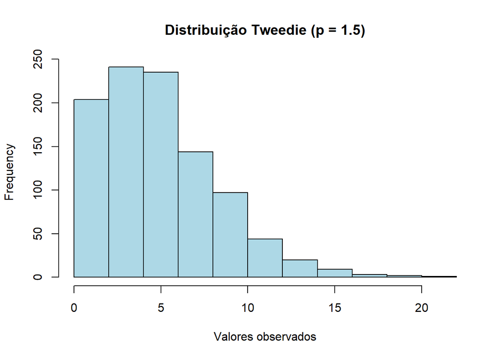

```r
# Exemplo de simulação e inspeção de dados Tweedie
# (requer pacotes tweedie e statmod)
# install.packages(c("tweedie", "statmod"))

library(tweedie)
set.seed(123)
y <- rtweedie(1000, mu = 5, phi = 1, power = 1.5)

hist(y, col = "lightblue", main = "Distribuição Tweedie (p = 1.5)",
     xlab = "Valores observados")
```

# 4 Prática zero inflacionados

Hipótese: A hipótese prevê um grande número de plantas intactas ou seja, represnta a ausência de herbivoria no habitat invadido.

Carregando pacotes a serem utilizados e importando o banco de dados

```r
library(glmmTMB) #Para rodar modelos ZIP/ZINB e ZAP/ZANB
#library(pscl) #Alternativa para modelos ZIP/ZINB e ZAP/ZANB
library(dplyr) #Manipulação dos dados
library(ggplot2) #Visualização
library(patchwork) #Para visualização de gráficos
#library(GGally) #Complemento ao ggplot2
#library(ggpubr) #Visualização
library(DHARMa) #Avaliação de modelos
library(performance) #Avaliação de modelos


dados <- readRDS("../Dados/plant_herbivore.rds")
```

## 4.1 Criando covariável exótica vs. nativa

```r
table(dados$Species)
```

```
##
##  SI  SL  SP  SV
## 100 164  82 129
```

```r
dados$tipo_planta <- ifelse(dados$Species == "SI", "invasora",
                            ifelse(dados$Species == "SL", "nativa",
                                   ifelse(dados$Species == "SP", "invasora", "nativa"))) %>% factor()

table(dados$tipo_planta)
```

```
##
## invasora   nativa
##      182      293
```

Desse modo, temos:

## 4.2 Transformando character para factor

```r
dados[, c("Subject","Location", "Species")] <- lapply(dados[, c("Subject","Location", "Species")], factor)
```

Para descobrir qual a frequência de zeros na variável resposta (damage):

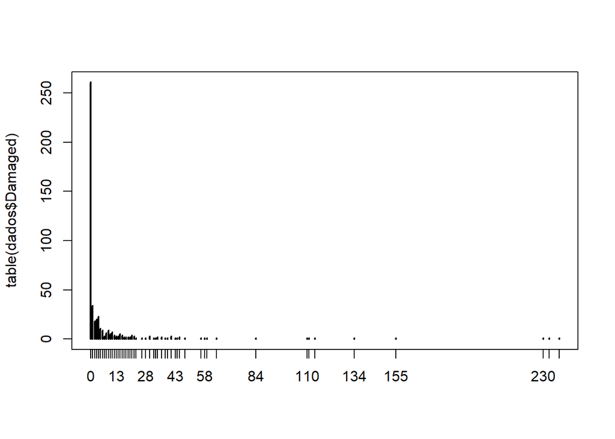

```r
plot(table(dados$Damaged))
```

```r
table(dados$Damaged == 0) # ~55% de zeros
```

```
##
## FALSE  TRUE
##   214   261
```

Há 261 dados com ZERO!

## 4.3 Há um padrão entre os 2 tipos de plantas?

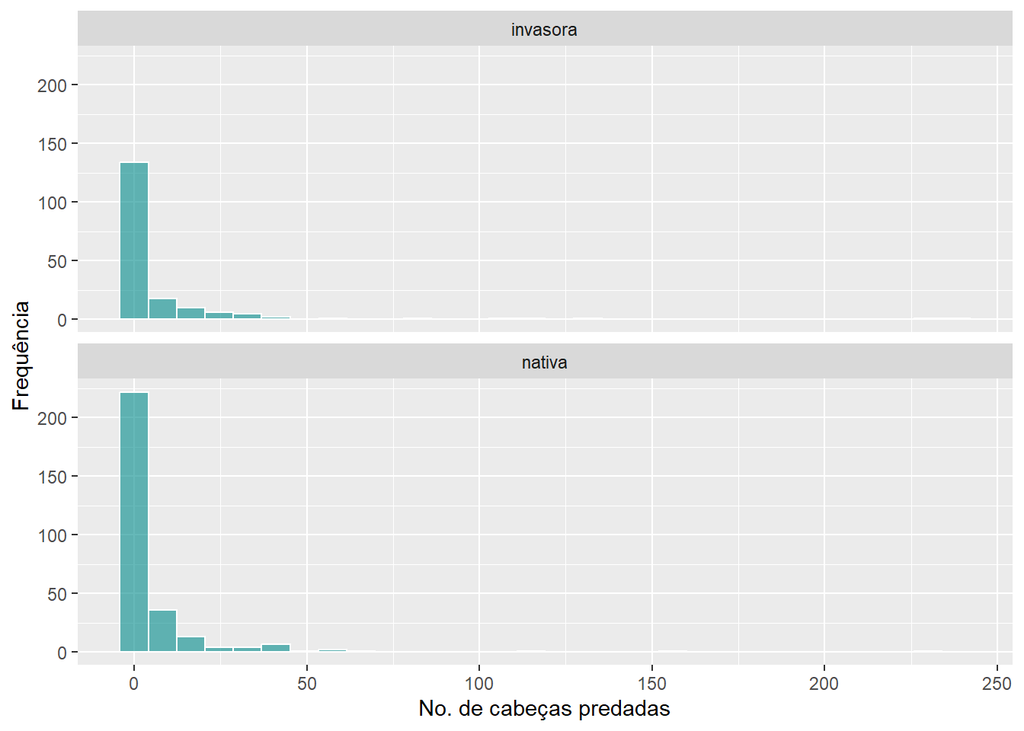

```r
dados %>%
  ggplot(aes(x = Damaged)) +
  geom_histogram(fill = "cyan4", alpha = 0.6, col = 'white') +
  facet_wrap(. ~ tipo_planta, ncol = 1) +
  labs(x = "No. de cabeças predadas", y = "Frequência")
```

Sim, dados os resultados dos gráficos, temos de fato, uma frequência para espécies invasoras e nativas.

## 4.4 Houve algum efeito do local de coleta, i.e., area em que se registrou mais predação?

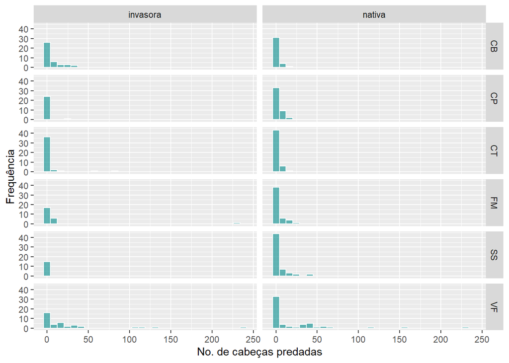

```r
dados %>%
  ggplot(aes(x = Damaged)) +
  geom_histogram(fill = "cyan4", alpha = 0.6, col = 'white') +
  facet_grid(Location ~ tipo_planta) +
  labs(x = "No. de cabeças predadas", y = "Frequência")
```

Sim, houve variação!

Ajustando o gráfico: melhorando a distribuição e visualização dos dados.

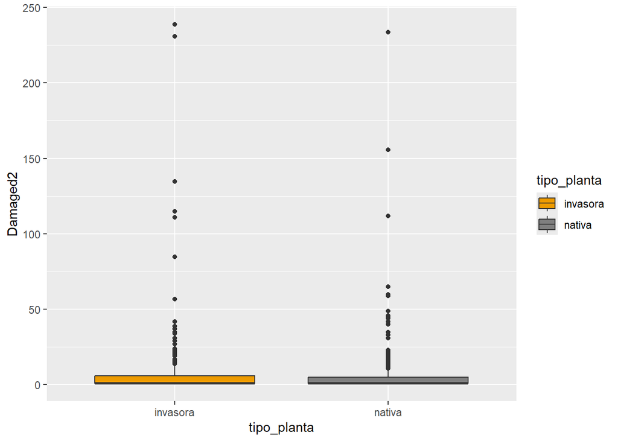

```r
dados %>%
  mutate(Damaged2 = Damaged + (mean(Damaged) * 0.10)) %>%
  ggplot(aes(x = tipo_planta, y = Damaged2, fill = tipo_planta)) +
  geom_boxplot() +
  scale_fill_manual(values = c("#ee9b00", "gray50"))
```

```r
dados %>%
  group_by(tipo_planta) %>%
  summarize(N_total = n(), #No. de plantas de cada tipo
            N_zeros = sum(Damaged == 0), #Frequência de zeros
            Proporcao_zeros = N_zeros / N_total, #Proporção de zeros
            Pred_tot = sum(Damaged),
            Pred_medio = mean(Damaged))
```

```
## # A tibble: 2 × 6
##   tipo_planta N_total N_zeros Proporcao_zeros Pred_tot Pred_medio
##   <fct>         <int>   <int>           <dbl>    <int>      <dbl>
## 1 invasora        182      99           0.544     1731       9.51
## 2 nativa          293     162           0.553     1886       6.44
```

- A proporção de zeros entre invasoras e nativas está semelhante.

## 4.5 Avaliando a proporção de zeros e sua frequência:

```r
dados %>%
  group_by(tipo_planta) %>%
  summarize(N_total = n(), #No. de plantas de cada tipo
            N_zeros = sum(Damaged == 0), #Frequência de zeros
            Proporcao_zeros = N_zeros / N_total, #Proporção de zeros
            Pred_tot = sum(Damaged),
            Pred_medio = mean(Damaged))
```

```
## # A tibble: 2 × 6
##   tipo_planta N_total N_zeros Proporcao_zeros Pred_tot Pred_medio
##   <fct>         <int>   <int>           <dbl>    <int>      <dbl>
## 1 invasora        182      99           0.544     1731       9.51
## 2 nativa          293     162           0.553     1886       6.44
```

## 4.6 Modelando os dados

### 4.6.1 Modelo ZIP

Vamos assumir que o número de cabeças de plantas predadas segue uma distribução ZIP, para isso, começaremos com um modelo simples, em que se assume apenas covariáveis no processo de contagem (Distribuição Poisson).

```r
## Modelo 1 - covariável apenas para o processo de contagem
ZIP1 <- glmmTMB(Damaged ~ tipo_planta,
                ziformula = ~ 1,
                data = dados,
                family = poisson(link = "log"))
```

Testando o Modelo 2 - covariável apenas para o processo de contagem:

```r
ZIP2 <- glmmTMB(Damaged ~ tipo_planta + Location,
                ziformula = ~ 1,
                data = dados,
                family = poisson(link = "log"))
```

Modelo 3 - Incluindo covariáveis para o processo de contagem e binário

```r
ZIP3 <- glmmTMB(Damaged ~ tipo_planta + Location,
                ziformula = ~ Species, #Testa a hipótese da liberação do inimigo (i.e., espécies invasoras (SI, SP) deveriam ter uma probabilidade maior de terem zeros)
                data = dados,
                family = poisson(link = "log"))
```

#### 4.6.1.1 Comparando os modelo mais ajustado aos dados:

```r
AIC(ZIP1, ZIP2, ZIP3)
```

```
##      df      AIC
## ZIP1  3 8249.738
## ZIP2  8 6164.004
## ZIP3 11 6037.068
```

O modelo 3 é o melhor, com menor AIC.

#### 4.6.1.2 Há sobredispersão além da dispersão causada pelo excesso de zeros?

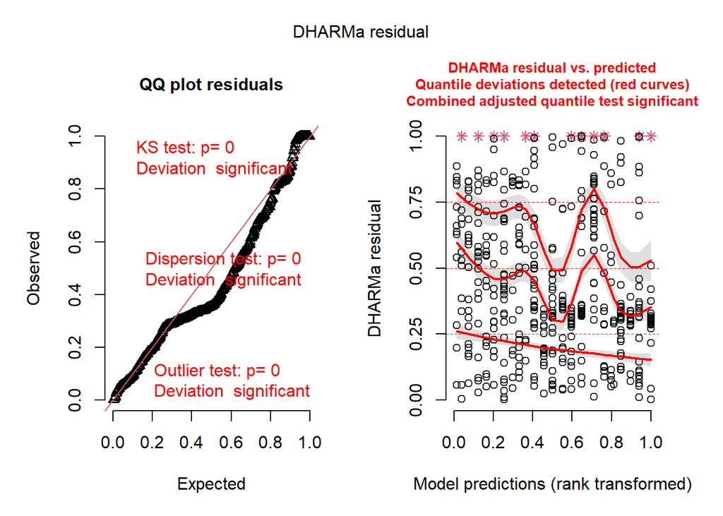

```r
simres <- simulateResiduals(ZIP3, n=1000)
plot(simres)
```

Sim! e ainda outros problemas no ajuste dos resíduos

Testando um modelo de distribuição Binomial Negativa

### 4.6.2 Modelo ZINB

```r
ZINB1 <- glmmTMB(Damaged ~ tipo_planta + Location,
                 ziformula = ~ Species, #Testa a hipótese da liberação do inimigo (i.e., espécies invasoras (SI, SP) deveriam ter uma probabilidade maior de terem zeros)
                 data = dados,
                 family = nbinom2(link = "log")) #nbinom1 = variancia aumenta linearmente com a media; nbino2 = variância aumenta quadraticamente com a media (formulacao mais comum)
```

#### 4.6.2.1 Avaliando qual o melhor modelo:

```r
AIC(ZIP3, ZINB1) #Eita!
```

```
##       df      AIC
## ZIP3  11 6037.068
## ZINB1 12 1998.567
```

Grande diferença!